# Approche adoptée pour la prévision de flux sur les donneés SIWIM

# Introduction

L’objet de cette page est de présenter l’approche adoptée pour analyser les donneés temporelles associées aux camions et captées par le système SIWIM, puis pour construire le meilleur modèle de prédiction possible.

# 1. Calcul des données avec le pas temporel donné

Nous avons décidé de partir sur une prévision dans l’heure, donc nous allons agréger les donnnées par date et par heure. Par cette opération, nous allons compter le nombre de camions, sommer les poids et les distances entre esseiux des camions et enfin prendre la moyenne de température, de la vitesse des camions.

Nous créeons ensuite un certain nombre de variables catégorielles et numériques autour du temps (année, mois, semaine, jour, jour de la semaine.

Voici une réprésentation graphique des différentes données :

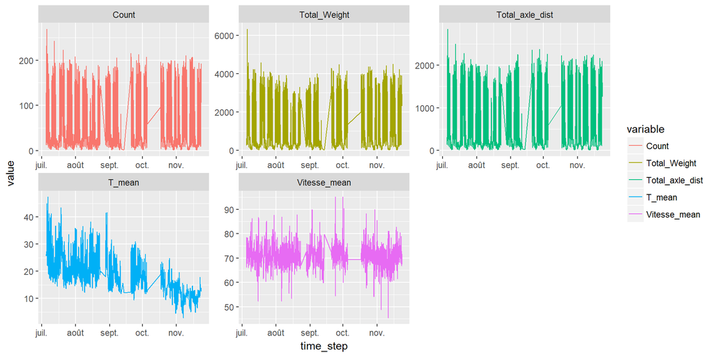

Quelques indications de la disribution par jour et par heure.

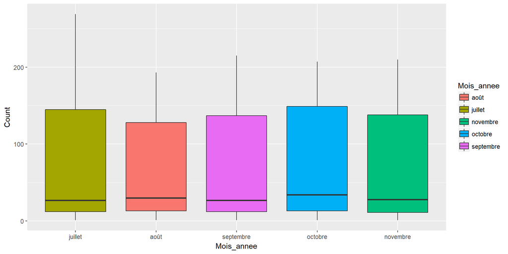

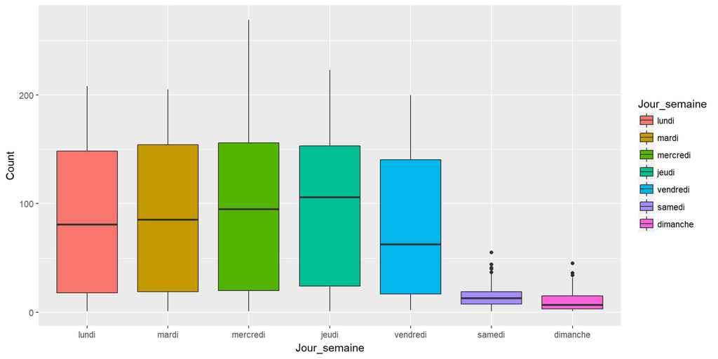

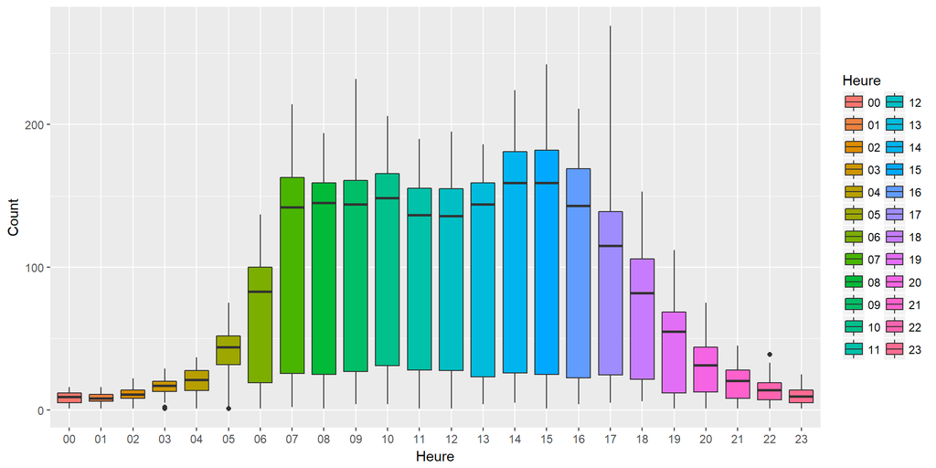

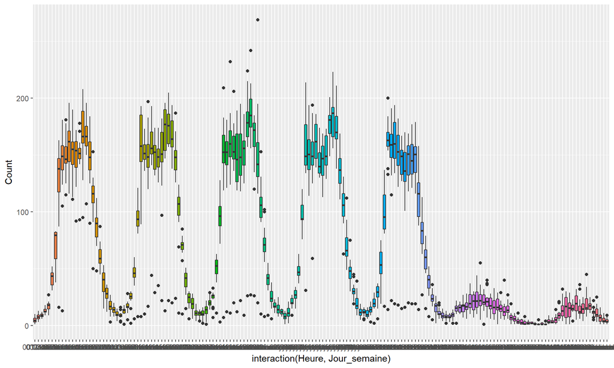

# 2. Gestion des valeurs manquantes (dates et heures)

Plusieurs périodes montrent un manque de données dû surement à une défection du système SIWIM. L’idee est de reconstituer les valeurs de fréquences par interpolation linéaire ou spline. Pour cela, nous allons compléter la série temporelle par les dates et heures manquantes.

| Dates et heures manquantes |
| --- |
| 2017-10-13 21:00:00 |
| 2017-11-18 23:00:00 |
| 2017-09-13 13:00:00 |
| 2017-09-15 15:00:00 |
| 2017-10-08 08:00:00 |

Nous construisons un nouveau data set uniquement pour les dates et heures manquantes. Les données catégorielles et numériques liées au temps sont déduites en même temps. Enfin, nous fusionnons le dataset de données existantes avec celui contenant les données manquantes.

Nous réalisons ensuite une interpolation linéaire et spline sur le dataset complet.

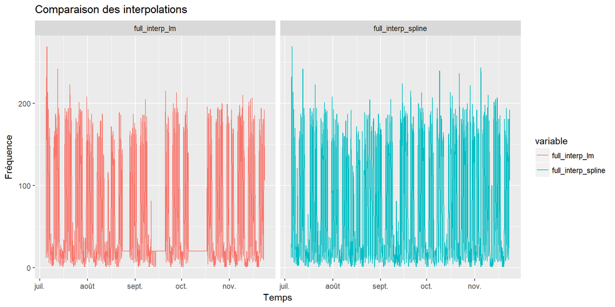

L’interpolation spline semble mieux compléter la série temporelle.

# 3. Modèles classiques de séries temporelles

Avant d’utiliser d’appliquer un modèle classique sur les séries temporelles, nous devons vérifier si elle est stationnaire. Une série temporelle stationnaire doit satisfaire 3 critères :

- sa moyenne doit être constante dans le temps
- sa variance doit être indépendante du temps
- la covariance entre termes doit être indépendante du temps.

## 3.1 ARIMA : Auto-regressive integrated moving average

Un modèle ARIMA cherche à prédire la valeur d’une série temporelle en fonction de ses valeurs précédentes ($y_t = f(y_{t-1}, y_{t-2}, …)$).

Les processus autorégressifs supposent que chaque point peut être prédit par la somme pondérée d’un ensemble de points précédents, plus un terme aléatoire d’erreur.

Le processus d’intégration suppose que chaque point présente une différence constante avec le point précédent.

Les processus de moyenne mobile supposent que chaque point est fonction des erreurs entachant les points précédant, plus sa propre erreur. Un modèle ARIMA est étiqueté comme modèle ARIMA (p,d,q), dans lequel : + p est le nombre de termes auto-régressifs + d est le nombre de différences + q est le nombre de moyennes mobiles.

La différentiation d’une série est nécessaire pour éliminer toute tendance et atteindre la stationnarité. Dans notre cas, la série est dèjà stationnaire (test de Dickey-Fuller). L’ordre d de différenciation (I integrated en anglais) sera systématiquement à 0.

Les modèles auto-régressifs supposent que yt est une fonction linéaire des valeurs précédentes.

$y_t = \mu + \Phi_1 y_{t-1} + \Phi_2 y_{t-2} + \Phi_3 y_{t-3} + \epsilon_t$

Les modèles à moyenne mobile suggèrent que la série présente des fluctuations autour d’une valeur moyenne. On considère alors que la meilleure estimation est représentée par la moyenne pondérée d’un certain nombre de valeurs antérieures (ce qui est le principe des procédures de moyennes mobiles utilisées pour le lissage des données). Ceci revient en fait à considérer que l’estimation est égal à la moyenne vraie, auquel on ajoute une somme pondérée des erreurs ayant entaché les valeurs précédentes :

$y_t = \mu - \theta_1 \epsilon_{t-1} - \theta_2 \epsilon_{t-2} - \theta_3 \epsilon_{t-3} + \epsilon_t$

## 3.2 Le test de Dickey-fuller

Le test de Dickey-fuller a pour hypothèse $H_0$ qu’une racine unitaire est présente dans une modèle auto-regressif d’ordre 1. L’hypothèse alternative est la stationnarité de la série temporelle.

$y_t = \rho y_{t-1} + u_t$. Une racine unitaire est présente si $\rho = 1$.

Cette équation est reformulée par différence de $y_t$ avec $y_{t-1}$ : $\nabla y_t = (\rho - 1) y_{t-1} + u_t = \delta y_{t-1} + u_t$

L’hypothèse $H_0$ devient : $\delta = 0$. 2 autres versions du test existent : + avec une constante intiale : $y_t = a_0 + \rho y_{t-1} + u_t$ + avec une tendance temporelle : $y_t = a_0 + a_1 t+ \rho y_{t-1} + u_t$

Le test augmenté de Dickey-fuller supprime tous les effets structurels dus aux autocorrelations d’ordre supérieur à 1.

```
##
##  Augmented Dickey-Fuller Test
##
## data:  siwim_data_hours$Count
## Dickey-Fuller = -3.6732, Lag order = 168, p-value = 0.02561
## alternative hypothesis: stationary
```

Le nombre de différences requises pour que la série soit stationnaire est de $0$

## 3.3 Tests de différents modèles ARIMA

### 3.3.1 ARIMA autoregressif d’ordre 1

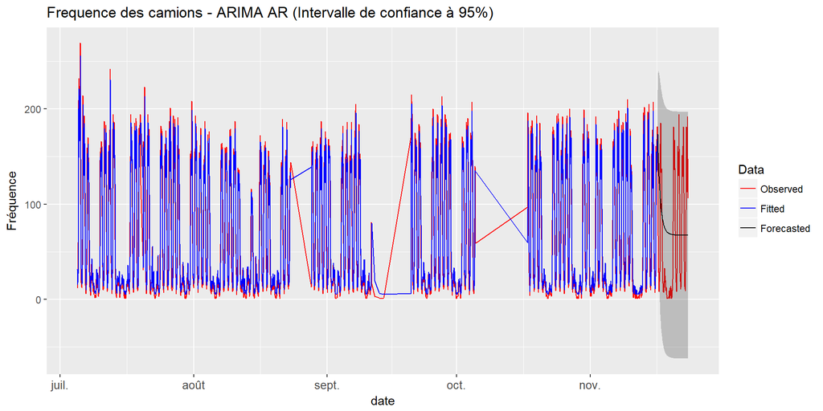

### 3.3.2 ARIMA moyenne mobile d’ordre 1

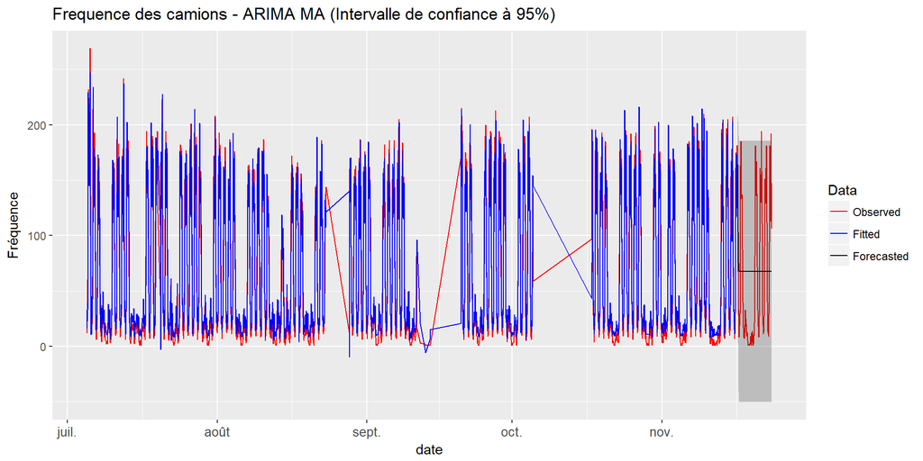

### 3.3.3 ARIMA auto

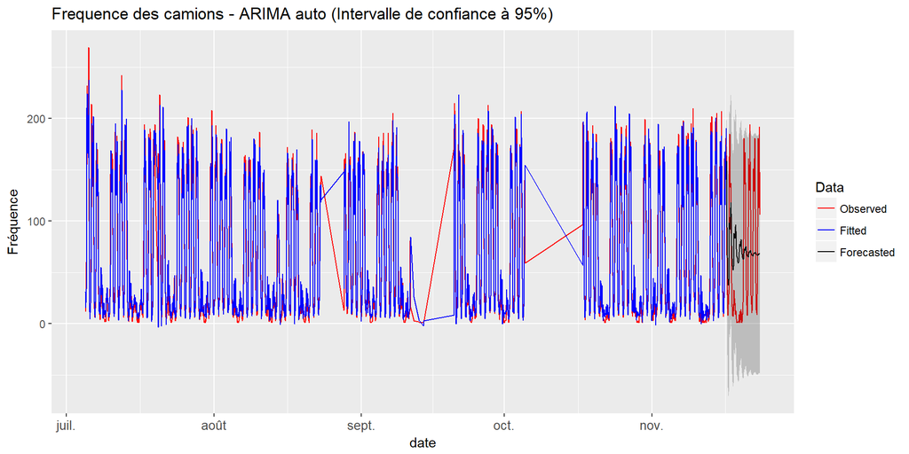

### 3.3.4 ARIMA avec une saisonnalité (24 heures)

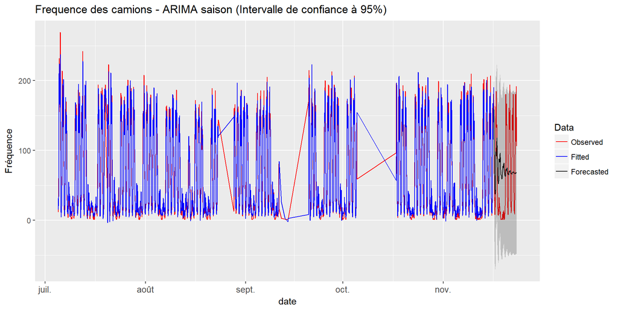

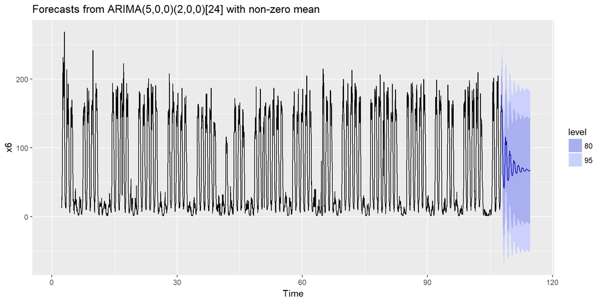

### 3.3.6 Résultats des erreurs par modèle ARIMA

Voici les différents types d’erreurs présentées pour comparer les modèles :

- Mean error : $ME = mean(e_i)$ où $e_i$ est l’erreur de prévision ppur l’observation i ($e_i = \hat{y}_i - y_i$)
- Root mean squared error : $RMSE = \sqrt{mean(e_i^2)}$
- Mean Absolute Error : $MAE = mean(|e_i|)$
- Mean pourcentage error : $MPE = mean(p_i)$ où $p_i$ est le pourcentage d’erreur ($p_i = 100 \frac{e_i}{y_i}$)
- Mean absolute percentage error: $MAPE = mean(|p_i|)$
- Mean absolute scaled error : $MASE = mean(|q_i|) = \frac{MAE}{Q}$ où $q_i$ est l’erreur mis à l’échelle de la moyenne des écarts entre chaque obeservation consécutive ($q_i = y_i - y_{i-1}$)

  |  | ME | RMSE | MAE | MPE | MAPE | MASE | ACF1 |
  | --- | --- | --- | --- | --- | --- | --- | --- |
  | Modèle AR | 0.0551125 | 23.44477 | 15.64161 | -42.58471 | 59.65201 | 1.0077004 | 0.2510202 |
  | Modèle MA | 0.0129023 | 22.13703 | 15.36456 | -67.18720 | 82.54818 | 0.9898522 | 0.0101378 |
  | Modèle auto ARIMA | 0.0286759 | 20.37799 | 13.58248 | -44.71983 | 64.20429 | 0.3918990 | 0.0004520 |
  | Modèle ARIMA avec saison | 0.0286759 | 20.37799 | 13.58248 | -44.71983 | 64.20429 | 0.3918990 | 0.0004520 |
  | Modèle ARIMA avec double saison | 0.0364122 | 20.43041 | 13.51384 | -41.33014 | 60.19032 | 0.3870543 | -0.0007796 |

## 3.4 Holt winters ou lissage exponentiel

### 3.4.1 Lissage exponentiel simple

Le lissage exponentiel simple consiste à donner plus d’importance aux dernières observations. On ne prolonge pas une série comme on le ferait avec une régression simple mais on cherche à obtenir une valeur lissée en t pour la reporter tout simplement en t + 1. La formule est la suivante :

$$\hat{y}_t = \alpha y_t + (1 - \alpha) \hat{y}_{t-1}$$

où $\alpha$ est le facteur de lissage compris entre 0 et 1.

En transformant la formule ci-dessus, on constate que la prévision à t est celle à t-1, à laquelle on ajoute l’erreur de prévision pondérée par le facteur de lissage.

$$\hat{y}_t = \alpha e_t + \hat{y}_{t-1}$$

On obtient par récurrence :

$$\hat{y}_t = \alpha y_t + \alpha (1 - \alpha) y_{t-1} + \alpha (1 - \alpha)^2 y_{t-2} + \alpha (1 - \alpha)^3 y_{t-3} + ...$$

Le lissage est exponentiel car la pondération de chaque terme décroit de manière exponentielle avec le temps.

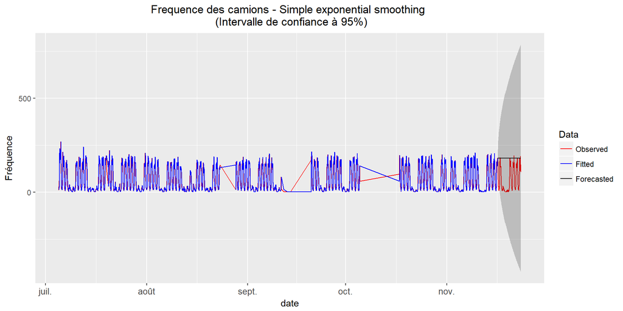

### 3.4.2 Lissage exponentiel triple ou Holt Winters

Le lissage Holt Winters consiste à rajouter 2 coefficients supplémentaires : $\gamma$ pour la tendance et $\delta$ pour la saisonnalité.

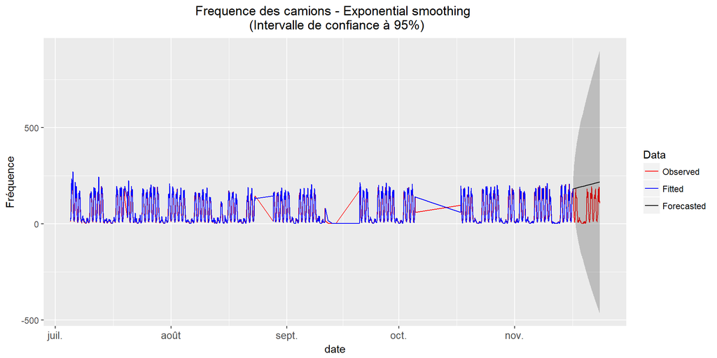

### 3.4.3 Résultats des modèles de lissage exponentiel

|  | ME | RMSE | MAE | MPE | MAPE | MASE | ACF1 |
| --- | --- | --- | --- | --- | --- | --- | --- |
| Sipmle Expoential Smoothing | 0.0660460 | 23.83423 | 15.52235 | -13.43676 | 40.45712 | 0.4478706 | 0.2272056 |
| Expoential Smoothing | -0.4874021 | 23.86568 | 15.59277 | -17.08559 | 42.09580 | 0.4499023 | 0.2274684 |

# 4. Modèles d’apprentissage automatique

## 4.1 Premier modèle linéaire simple

Le premier modèle linéaire simple consiste à prendre simplement l’heure et le jour de la semaine en considération en tant que variables catégorielles.

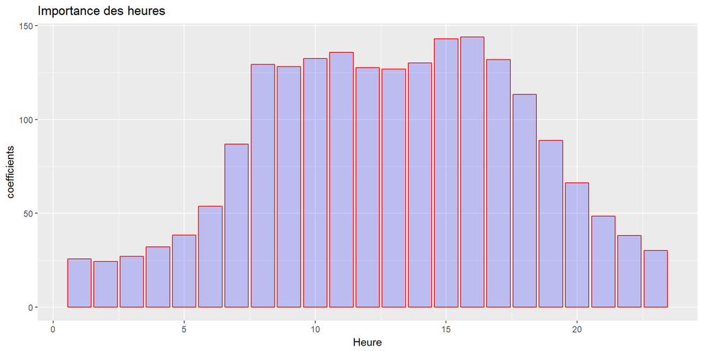

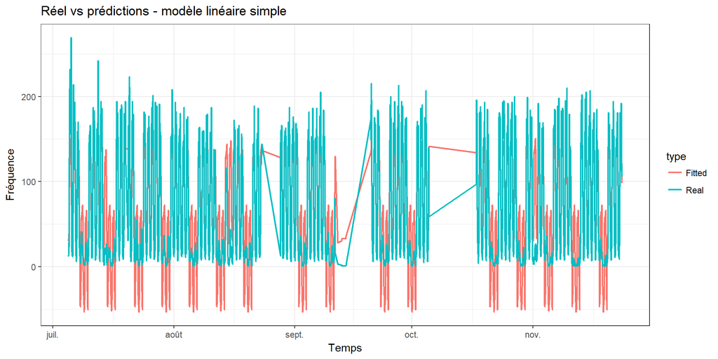

## 4.2 Modèle linéaire avec interactions

Le deuxième modèle linéaire vient ajouter une interaction entre les 2 variables catégorielles considérées précédemment.

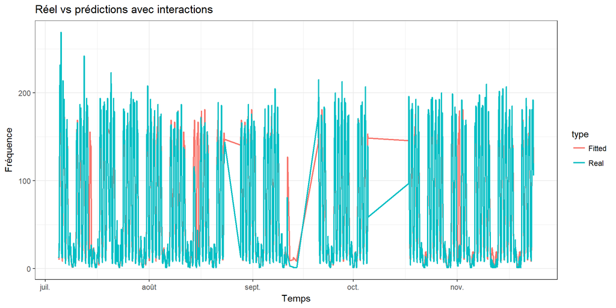

Le $R^2$ ajusté évolue favorablement :

```
##  Previous       New
## 0.8779472 0.9515936
```

## 4.3 Sélection de variables de lags par stepwise pour les autres modèles

La suite des modèles d’apprentissage automatique considére toujours l’heure et le jour de la semaine en tant que variables catégorielles et sans intéractions. Ils prennent aussi en compte des variables de lags (valeurs de la série temporelle dans le passé). Etant donnée la saisonnalité de la série, j’ai considéré les lags de 1 à 168 heures (1 semaine) dans le passé.

Comme cela fait beaucoup de variables à considérer, j’ai réalisé une pré-sélection par stepwise (forward et backward) en considérant le critère BIC.

Résultats de la sélection (critère BIC) :

| Variables | Coefficients |
| --- | --- |
| (Intercept) | 9.5942176 |
| Heure01 | -1.0902087 |
| Heure02 | 0.5420598 |
| Heure03 | 2.6408817 |
| Heure04 | 1.6317783 |
| Heure05 | 11.8632568 |
| Heure06 | 26.8485504 |
| Heure07 | 43.3291914 |
| Heure08 | 9.6708157 |
| Heure09 | 11.9255483 |
| Heure10 | 17.9223471 |
| Heure11 | 10.3027640 |
| Heure12 | 12.3987484 |
| Heure13 | 19.0292602 |
| Heure14 | 28.5394627 |
| Heure15 | 21.8909486 |
| Heure16 | 11.0817806 |
| Heure17 | 2.3916850 |
| Heure18 | -3.6280700 |
| Heure19 | -6.4340170 |
| Heure20 | -7.4260096 |
| Heure21 | -5.5811897 |
| Heure22 | -4.7300882 |
| Heure23 | -2.1458812 |
| Jour_semainedimanche | -12.3122327 |
| Jour_semainejeudi | 2.7551919 |
| Jour_semainemardi | -2.1659872 |
| Jour_semainemercredi | 3.0281011 |
| Jour_semainesamedi | -12.3127773 |
| Jour_semainevendredi | 0.9240597 |
| lag_1 | 0.7511478 |
| lag_2 | 0.1428795 |
| lag_4 | -0.0563702 |
| lag_9 | -0.1076888 |
| lag_15 | 0.0586956 |
| lag_23 | 0.0529971 |
| lag_27 | -0.0828603 |
| lag_29 | 0.0567132 |
| lag_45 | -0.0639339 |
| lag_95 | -0.0429854 |
| lag_100 | 0.0306807 |
| lag_111 | -0.0225753 |
| lag_143 | 0.0235788 |
| lag_164 | 0.0307346 |
| lag_168 | -0.0275310 |
| lag_90 | 0.0257868 |

## 4.4 Valdation croisée pour les séries temporelles

Les séries temporelles sont des observations ordonnées chronologiquement. Ainsi, contrairment aux données non temporelles, leur ordre a une importance dont il faut tenir compte lors de la validation croisée. Pour cela 2 approches existent :

- estimation du modèle sur un sous-échantillon dont la taille augmente de façon incrémentale, en tenant compte de l’odre temporel des données. La prévision est réalisée sur les valeurs postérieures à cet échantillon pour un horizon de prévision donné.
- estimation du modèle sur un groupe défini par une fenêtre glissante de taille fixe. La prévision est réalisée sur les valeurs postérieures à cet échantillon pour un horizon de prévision donné.

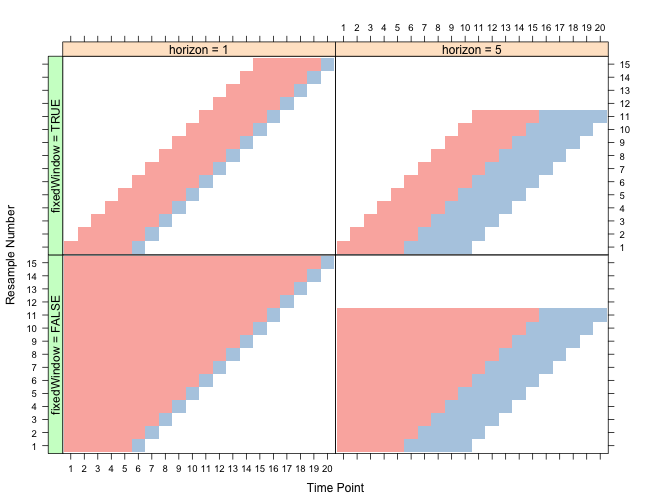

Validation croisée sur série temporelle

## 4.5 Modèles entrainés avec validation croisée

- Regression linéaire simple : Heure et Jour_semaine
- Regression linéaire simple avec interactions : Heure et Jour_semaine
- Regression linéaire simple avec lags : Heure et Jour_semaine (sans interactions) avec lags choisis par selection stepwise (BIC)
- Régression pénalisée (ridge/lasso/elasticnet)
  - facteur de pénalisation : $\lambda : {\color{red}1}, 10, 50, 100, 200, 500, 1000$
- Random forest
  - Nombre de variabes choisies aléatoirement à chaque split (mtry) :
    $$1,\sqrt{p}$$
  - Nombre d’arbres : 500
- Gradient boosting
  - Nombre d’interactions (n.trees) : 100, 500, 1000, 1500
  - nombre de noeuds terminaux des arbres plus 1 (interaction.depth) : 1, 5, 9
  - paramètre de régularisation ($\lambda$) : 0.1
  - Nombre minimum d’individus dans chaque feuille : 20